# Bellabeat Device Usage Analysis

Hrithik Sharma

2023-10-02

# Introduction

In this case study, you step into the role of a junior data analyst at Bellabeat, a forward-thinking company specializing in health-focused smart products for women. Bellabeat, founded by Urška Sršen and Sando Mur, has made significant strides in the health technology industry, offering products that empower women with valuable insights into their activity, sleep, stress, and reproductive health. Despite their success, the company seeks to expand further in the global smart device market and believes that analyzing smart device fitness data can unlock new growth opportunities.

Your task as a data analyst is to focus on one of Bellabeat’s products and thoroughly analyze the data generated by these smart devices. By dissecting how consumers are utilizing these devices, you aim to provide critical insights that will shape the company’s marketing strategy. Bellabeat’s CCO, Urška Sršen, is eager to leverage the available consumer data to uncover untapped growth potential. This analysis will help inform high-level recommendations for Bellabeat’s marketing approach, allowing them to harness the power of data-driven insights to drive future success. As you embark on this case study, you will follow the data analysis process, from asking the right questions to sharing your findings and making actionable recommendations to the Bellabeat executive team.

# Set Up Business Objective

Identify trends in how consumers use non-Bellabeat smart devices to apply insights into Bellabeat’s marketing strategy.

**Stakeholders**

Urška Sršen - Bellabeat cofounder and Chief Creative Officer Sando Mur - Bellabeat cofounder and key member of Bellabeat executive team Bellabeat Marketing Analytics team

# Preparing and Sourcing the Dataset

## Installing Packages

```r
#Install and Load Packages
install.packages("tidyverse")
install.packages("dplyr")
install.packages("janitor")
```

```r
install.packages("ggplot2")
install.packages("lubridate")
library(tidyverse)
library(dplyr)
library(janitor)
library(ggplot2)
library(lubridate)
```

## Importing Datasets

```r
daily_activity <- read.csv("D:/Data_Analysis/BellabeatAnalysis/Data/dailyActivity_merged.csv")
head(daily_activity)
```

```
##           Id ActivityDate TotalSteps TotalDistance TrackerDistance
## 1 1503960366    4/12/2016      13162          8.50            8.50
## 2 1503960366    4/13/2016      10735          6.97            6.97
## 3 1503960366    4/14/2016      10460          6.74            6.74
## 4 1503960366    4/15/2016       9762          6.28            6.28
## 5 1503960366    4/16/2016      12669          8.16            8.16
## 6 1503960366    4/17/2016       9705          6.48            6.48
##   LoggedActivitiesDistance VeryActiveDistance ModeratelyActiveDistance
## 1                        0               1.88                     0.55
## 2                        0               1.57                     0.69
## 3                        0               2.44                     0.40
## 4                        0               2.14                     1.26
## 5                        0               2.71                     0.41
## 6                        0               3.19                     0.78
##   LightActiveDistance SedentaryActiveDistance VeryActiveMinutes
## 1                6.06                       0                25
## 2                4.71                       0                21
## 3                3.91                       0                30
## 4                2.83                       0                29
## 5                5.04                       0                36
## 6                2.51                       0                38
##   FairlyActiveMinutes LightlyActiveMinutes SedentaryMinutes Calories
## 1                  13                  328              728     1985
## 2                  19                  217              776     1797
## 3                  11                  181             1218     1776
## 4                  34                  209              726     1745
## 5                  10                  221              773     1863
## 6                  20                  164              539     1728
```

```r
str(daily_activity)
```

```
## 'data.frame':    940 obs. of  15 variables:
##  $ Id                      : num  1.5e+09 1.5e+09 1.5e+09 1.5e+09 1.5e+09 ...
##  $ ActivityDate            : chr  "4/12/2016" "4/13/2016" "4/14/2016" "4/15/2016" ...
##  $ TotalSteps              : int  13162 10735 10460 9762 12669 9705 13019 15506 10544 9819 ...
##  $ TotalDistance           : num  8.5 6.97 6.74 6.28 8.16 ...
##  $ TrackerDistance         : num  8.5 6.97 6.74 6.28 8.16 ...
##  $ LoggedActivitiesDistance: num  0 0 0 0 0 0 0 0 0 0 ...
##  $ VeryActiveDistance      : num  1.88 1.57 2.44 2.14 2.71 ...
##  $ ModeratelyActiveDistance: num  0.55 0.69 0.4 1.26 0.41 ...
##  $ LightActiveDistance     : num  6.06 4.71 3.91 2.83 5.04 ...
##  $ SedentaryActiveDistance : num  0 0 0 0 0 0 0 0 0 0 ...
##  $ VeryActiveMinutes       : int  25 21 30 29 36 38 42 50 28 19 ...
##  $ FairlyActiveMinutes     : int  13 19 11 34 10 20 16 31 12 8 ...
##  $ LightlyActiveMinutes    : int  328 217 181 209 221 164 233 264 205 211 ...
##  $ SedentaryMinutes        : int  728 776 1218 726 773 539 1149 775 818 838 ...
##  $ Calories                : int  1985 1797 1776 1745 1863 1728 1921 2035 1786 1775 ...
```

```r
daily_calories <- read.csv("D:/Data_Analysis/BellabeatAnalysis/Data/dailyCalories_merged.csv")
head(daily_calories)
```

```
##           Id ActivityDay Calories
## 1 1503960366   4/12/2016     1985
## 2 1503960366   4/13/2016     1797
## 3 1503960366   4/14/2016     1776
## 4 1503960366   4/15/2016     1745
## 5 1503960366   4/16/2016     1863
## 6 1503960366   4/17/2016     1728
```

```r
str(daily_calories)
```

```
## 'data.frame':    940 obs. of  3 variables:
##  $ Id         : num  1.5e+09 1.5e+09 1.5e+09 1.5e+09 1.5e+09 ...
##  $ ActivityDay: chr  "4/12/2016" "4/13/2016" "4/14/2016" "4/15/2016" ...
##  $ Calories   : int  1985 1797 1776 1745 1863 1728 1921 2035 1786 1775 ...
```

```r
daily_intensities <- read.csv("D:/Data_Analysis/BellabeatAnalysis/Data/dailyIntensities_merged.csv")
head(daily_intensities)
```

```
##           Id ActivityDay SedentaryMinutes LightlyActiveMinutes
## 1 1503960366   4/12/2016              728                  328
## 2 1503960366   4/13/2016              776                  217
## 3 1503960366   4/14/2016             1218                  181
## 4 1503960366   4/15/2016              726                  209
## 5 1503960366   4/16/2016              773                  221
## 6 1503960366   4/17/2016              539                  164
##   FairlyActiveMinutes VeryActiveMinutes SedentaryActiveDistance
## 1                  13                25                       0
## 2                  19                21                       0
## 3                  11                30                       0
## 4                  34                29                       0
## 5                  10                36                       0
## 6                  20                38                       0
##   LightActiveDistance ModeratelyActiveDistance VeryActiveDistance
## 1                6.06                     0.55               1.88
## 2                4.71                     0.69               1.57
## 3                3.91                     0.40               2.44
## 4                2.83                     1.26               2.14
## 5                5.04                     0.41               2.71
## 6                2.51                     0.78               3.19
```

```r
str(daily_intensities)
```

```
## 'data.frame':    940 obs. of  10 variables:
##  $ Id                      : num  1.5e+09 1.5e+09 1.5e+09 1.5e+09 1.5e+09 ...
##  $ ActivityDay             : chr  "4/12/2016" "4/13/2016" "4/14/2016" "4/15/2016" ...
##  $ SedentaryMinutes        : int  728 776 1218 726 773 539 1149 775 818 838 ...
##  $ LightlyActiveMinutes    : int  328 217 181 209 221 164 233 264 205 211 ...
##  $ FairlyActiveMinutes     : int  13 19 11 34 10 20 16 31 12 8 ...
##  $ VeryActiveMinutes       : int  25 21 30 29 36 38 42 50 28 19 ...
##  $ SedentaryActiveDistance : num  0 0 0 0 0 0 0 0 0 0 ...
##  $ LightActiveDistance     : num  6.06 4.71 3.91 2.83 5.04 ...
##  $ ModeratelyActiveDistance: num  0.55 0.69 0.4 1.26 0.41 ...
##  $ VeryActiveDistance      : num  1.88 1.57 2.44 2.14 2.71 ...
```

```r
daily_steps <- read.csv("D:/Data_Analysis/BellabeatAnalysis/Data/dailySteps_merged.csv")
head(daily_steps)
```

```
##           Id ActivityDay StepTotal
## 1 1503960366   4/12/2016     13162
## 2 1503960366   4/13/2016     10735
## 3 1503960366   4/14/2016     10460
## 4 1503960366   4/15/2016      9762
## 5 1503960366   4/16/2016     12669
## 6 1503960366   4/17/2016      9705
```

```r
str(daily_steps)
```

```
## 'data.frame':    940 obs. of  3 variables:
##  $ Id         : num  1.5e+09 1.5e+09 1.5e+09 1.5e+09 1.5e+09 ...
##  $ ActivityDay: chr  "4/12/2016" "4/13/2016" "4/14/2016" "4/15/2016" ...
##  $ StepTotal  : int  13162 10735 10460 9762 12669 9705 13019 15506 10544 9819 ...
```

```r
heartrate <- read.csv("D:/Data_Analysis/BellabeatAnalysis/Data/heartrate_seconds_merged.csv")
head(heartrate)
```

```
##           Id                 Time Value
## 1 2022484408 4/12/2016 7:21:00 AM    97
## 2 2022484408 4/12/2016 7:21:05 AM   102
## 3 2022484408 4/12/2016 7:21:10 AM   105
## 4 2022484408 4/12/2016 7:21:20 AM   103
## 5 2022484408 4/12/2016 7:21:25 AM   101
## 6 2022484408 4/12/2016 7:22:05 AM    95
```

```r
str(heartrate)
```

```
## 'data.frame':    2483658 obs. of  3 variables:
##  $ Id   : num  2.02e+09 2.02e+09 2.02e+09 2.02e+09 2.02e+09 ...
##  $ Time : chr  "4/12/2016 7:21:00 AM" "4/12/2016 7:21:05 AM" "4/12/2016 7:21:10 AM" "4/12/2016 7:21:20 AM" ...
##  $ Value: int  97 102 105 103 101 95 91 93 94 93 ...
```

```r
hourly_calories <- read.csv("D:/Data_Analysis/BellabeatAnalysis/Data/hourlyCalories_merged.csv")
head(hourly_calories)
```

```
##           Id          ActivityHour Calories
## 1 1503960366 4/12/2016 12:00:00 AM       81
## 2 1503960366  4/12/2016 1:00:00 AM       61
## 3 1503960366  4/12/2016 2:00:00 AM       59
## 4 1503960366  4/12/2016 3:00:00 AM       47
## 5 1503960366  4/12/2016 4:00:00 AM       48
## 6 1503960366  4/12/2016 5:00:00 AM       48
```

```r
str(hourly_calories)
```

```
## 'data.frame':    22099 obs. of  3 variables:
##  $ Id          : num  1.5e+09 1.5e+09 1.5e+09 1.5e+09 1.5e+09 ...
##  $ ActivityHour: chr  "4/12/2016 12:00:00 AM" "4/12/2016 1:00:00 AM" "4/12/2016 2:00:00 AM" "4/12/2016 3:00:00 AM" ...
##  $ Calories    : int  81 61 59 47 48 48 48 47 68 141 ...
```

```r
hourly_intensities <- read.csv("D:/Data_Analysis/BellabeatAnalysis/Data/hourlyIntensities_merged.csv")
head(hourly_intensities)
```

```
##           Id          ActivityHour TotalIntensity AverageIntensity
## 1 1503960366 4/12/2016 12:00:00 AM             20         0.333333
## 2 1503960366  4/12/2016 1:00:00 AM              8         0.133333
## 3 1503960366  4/12/2016 2:00:00 AM              7         0.116667
## 4 1503960366  4/12/2016 3:00:00 AM              0         0.000000
## 5 1503960366  4/12/2016 4:00:00 AM              0         0.000000
## 6 1503960366  4/12/2016 5:00:00 AM              0         0.000000
```

```r
str(hourly_intensities)
```

```
## 'data.frame':    22099 obs. of  4 variables:
##  $ Id              : num  1.5e+09 1.5e+09 1.5e+09 1.5e+09 1.5e+09 ...
##  $ ActivityHour    : chr  "4/12/2016 12:00:00 AM" "4/12/2016 1:00:00 AM" "4/12/2016 2:00:00 AM" "4/12/2016 3:00:00 AM" ...
##  $ TotalIntensity  : int  20 8 7 0 0 0 0 0 13 30 ...
##  $ AverageIntensity: num  0.333 0.133 0.117 0 0 ...
```

```r
hourly_steps <- read.csv("D:/Data_Analysis/BellabeatAnalysis/Data/hourlySteps_merged.csv")
head(hourly_steps)
```

```
##           Id          ActivityHour StepTotal
## 1 1503960366 4/12/2016 12:00:00 AM       373
## 2 1503960366  4/12/2016 1:00:00 AM       160
## 3 1503960366  4/12/2016 2:00:00 AM       151
## 4 1503960366  4/12/2016 3:00:00 AM         0
## 5 1503960366  4/12/2016 4:00:00 AM         0
## 6 1503960366  4/12/2016 5:00:00 AM         0
```

```r
str(hourly_steps)
```

```
## 'data.frame':    22099 obs. of  3 variables:
##  $ Id          : num  1.5e+09 1.5e+09 1.5e+09 1.5e+09 1.5e+09 ...
##  $ ActivityHour: chr  "4/12/2016 12:00:00 AM" "4/12/2016 1:00:00 AM" "4/12/2016 2:00:00 AM" "4/12/2016 3:00:00 AM" ...
##  $ StepTotal   : int  373 160 151 0 0 0 0 0 250 1864 ...
```

```r
minute_steps <- read.csv("D:/Data_Analysis/BellabeatAnalysis/Data/minuteStepsNarrow_merged.csv")
head(minute_steps)
```

```
##           Id        ActivityMinute Steps
## 1 1503960366 4/12/2016 12:00:00 AM     0
## 2 1503960366 4/12/2016 12:01:00 AM     0
## 3 1503960366 4/12/2016 12:02:00 AM     0
## 4 1503960366 4/12/2016 12:03:00 AM     0
## 5 1503960366 4/12/2016 12:04:00 AM     0
## 6 1503960366 4/12/2016 12:05:00 AM     0
```

```r
str(minute_steps)
```

```
## 'data.frame':    1325580 obs. of  3 variables:
##  $ Id            : num  1.5e+09 1.5e+09 1.5e+09 1.5e+09 1.5e+09 ...
##  $ ActivityMinute: chr  "4/12/2016 12:00:00 AM" "4/12/2016 12:01:00 AM" "4/12/2016 12:02:00 AM" "4/12/2016 12:03:00 AM" ...
##  $ Steps         : int  0 0 0 0 0 0 0 0 0 0 ...
```

```r
minute_calories <- read.csv("D:/Data_Analysis/BellabeatAnalysis/Data/minuteCaloriesNarrow_merged.csv")
head(minute_calories)
```

```
##           Id        ActivityMinute Calories
## 1 1503960366 4/12/2016 12:00:00 AM   0.7865
## 2 1503960366 4/12/2016 12:01:00 AM   0.7865
## 3 1503960366 4/12/2016 12:02:00 AM   0.7865
## 4 1503960366 4/12/2016 12:03:00 AM   0.7865
## 5 1503960366 4/12/2016 12:04:00 AM   0.7865
## 6 1503960366 4/12/2016 12:05:00 AM   0.9438
```

```r
str(minute_calories)
```

```
## 'data.frame':    1325580 obs. of  3 variables:
##  $ Id            : num  1.5e+09 1.5e+09 1.5e+09 1.5e+09 1.5e+09 ...
##  $ ActivityMinute: chr  "4/12/2016 12:00:00 AM" "4/12/2016 12:01:00 AM" "4/12/2016 12:02:00 AM" "4/12/2016 12:03:00 AM" ...
##  $ Calories      : num  0.786 0.786 0.786 0.786 0.786 ...
```

```r
minute_intensities <- read.csv("D:/Data_Analysis/BellabeatAnalysis/Data/minuteIntensitiesNarrow_merged.csv")
head(minute_intensities)
```

```
##           Id        ActivityMinute Intensity
## 1 1503960366 4/12/2016 12:00:00 AM         0
## 2 1503960366 4/12/2016 12:01:00 AM         0
## 3 1503960366 4/12/2016 12:02:00 AM         0
## 4 1503960366 4/12/2016 12:03:00 AM         0
## 5 1503960366 4/12/2016 12:04:00 AM         0
## 6 1503960366 4/12/2016 12:05:00 AM         0
```

```r
str(minute_intensities)
```

```
## 'data.frame':    1325580 obs. of  3 variables:
##  $ Id            : num  1.5e+09 1.5e+09 1.5e+09 1.5e+09 1.5e+09 ...
##  $ ActivityMinute: chr  "4/12/2016 12:00:00 AM" "4/12/2016 12:01:00 AM" "4/12/2016 12:02:00 AM" "4/12/2016 12:03:00 AM" ...
##  $ Intensity     : int  0 0 0 0 0 0 0 0 0 0 ...
```

```r
minute_MET <- read.csv("D:/Data_Analysis/BellabeatAnalysis/Data/minuteMETsNarrow_merged.csv")
head(minute_MET)
```

```
##           Id        ActivityMinute METs
## 1 1503960366 4/12/2016 12:00:00 AM   10
## 2 1503960366 4/12/2016 12:01:00 AM   10
## 3 1503960366 4/12/2016 12:02:00 AM   10
## 4 1503960366 4/12/2016 12:03:00 AM   10
## 5 1503960366 4/12/2016 12:04:00 AM   10
## 6 1503960366 4/12/2016 12:05:00 AM   12
```

```r
str(minute_MET)
```

```
## 'data.frame':    1325580 obs. of  3 variables:
##  $ Id            : num  1.5e+09 1.5e+09 1.5e+09 1.5e+09 1.5e+09 ...
##  $ ActivityMinute: chr  "4/12/2016 12:00:00 AM" "4/12/2016 12:01:00 AM" "4/12/2016 12:02:00 AM" "4/12/2016 12:03:00 AM" ...
##  $ METs          : int  10 10 10 10 10 12 12 12 12 12 ...
```

```r
daily_sleep <- read.csv("D:/Data_Analysis/BellabeatAnalysis/Data/sleepDay_merged.csv")
head(daily_sleep)
```

```
##           Id              SleepDay TotalSleepRecords TotalMinutesAsleep
## 1 1503960366 4/12/2016 12:00:00 AM                 1                327
## 2 1503960366 4/13/2016 12:00:00 AM                 2                384
## 3 1503960366 4/15/2016 12:00:00 AM                 1                412
## 4 1503960366 4/16/2016 12:00:00 AM                 2                340
## 5 1503960366 4/17/2016 12:00:00 AM                 1                700
## 6 1503960366 4/19/2016 12:00:00 AM                 1                304
##   TotalTimeInBed
## 1            346
## 2            407
## 3            442
## 4            367
## 5            712
## 6            320
```

```r
str(daily_sleep)
```

```
## 'data.frame':    413 obs. of  5 variables:
##  $ Id                : num  1.5e+09 1.5e+09 1.5e+09 1.5e+09 1.5e+09 ...
##  $ SleepDay          : chr  "4/12/2016 12:00:00 AM" "4/13/2016 12:00:00 AM" "4/15/2016 12:00:00 AM" "4/16/2016 12:00:00 AM" ...
##  $ TotalSleepRecords : int  1 2 1 2 1 1 1 1 1 1 ...
##  $ TotalMinutesAsleep: int  327 384 412 340 700 304 360 325 361 430 ...
##  $ TotalTimeInBed    : int  346 407 442 367 712 320 377 364 384 449 ...
```

```r
weight_log <- read.csv("D:/Data_Analysis/BellabeatAnalysis/Data/weightLogInfo_merged.csv")
head(weight_log)
```

```
##           Id                  Date WeightKg WeightPounds Fat   BMI
## 1 1503960366  5/2/2016 11:59:59 PM     52.6     115.9631  22 22.65
## 2 1503960366  5/3/2016 11:59:59 PM     52.6     115.9631  NA 22.65
## 3 1927972279  4/13/2016 1:08:52 AM    133.5     294.3171  NA 47.54
## 4 2873212765 4/21/2016 11:59:59 PM     56.7     125.0021  NA 21.45
## 5 2873212765 5/12/2016 11:59:59 PM     57.3     126.3249  NA 21.69
## 6 4319703577 4/17/2016 11:59:59 PM     72.4     159.6147  25 27.45
##   IsManualReport        LogId
## 1           True 1.462234e+12
## 2           True 1.462320e+12
## 3          False 1.460510e+12
## 4           True 1.461283e+12
## 5           True 1.463098e+12
## 6           True 1.460938e+12
```

```r
str(weight_log)
```

```
## 'data.frame':    67 obs. of  8 variables:
##  $ Id            : num  1.50e+09 1.50e+09 1.93e+09 2.87e+09 2.87e+09 ...
##  $ Date          : chr  "5/2/2016 11:59:59 PM" "5/3/2016 11:59:59 PM" "4/13/2016 1:08:52 AM" "4/21/2016 11:59:59 PM" ...
##  $ WeightKg      : num  52.6 52.6 133.5 56.7 57.3 ...
##  $ WeightPounds  : num  116 116 294 125 126 ...
##  $ Fat           : int  22 NA NA NA NA 25 NA NA NA NA ...
##  $ BMI           : num  22.6 22.6 47.5 21.5 21.7 ...
##  $ IsManualReport: chr  "True" "True" "False" "True" ...
##  $ LogId         : num  1.46e+12 1.46e+12 1.46e+12 1.46e+12 1.46e+12 ...
```

# Cleaning and Preparing Dataset

## Working with Day wise activities Dataset

### 1. Clean daily activity data frame

```r
#Clean daily_activity
daily_activity %>%
  drop_na() %>%
  select(-ActivityDate) %>%
  select(-TotalSteps) %>%
  select(-TrackerDistance)
```

### 2. Return only unique values

```r
daily_activity <- unique(daily_activity)
```

### 3. Add aditional data such as day, month and day of week for analysis

```r
#Extract day, month and year from ActivityDate (daily_activity)
daily_activity$ActivityDate <- as.Date(daily_activity$ActivityDate, format = "%m/%d/%Y")
daily_activity$day <- format(as.Date(daily_activity$ActivityDate), "%d")
daily_activity$month <- format(as.Date(daily_activity$ActivityDate), "%m")
daily_activity$day_of_week <- format(as.Date(daily_activity$ActivityDate), "%A")

str(daily_activity)
```

```
## 'data.frame':    940 obs. of  18 variables:
##  $ Id                      : num  1.5e+09 1.5e+09 1.5e+09 1.5e+09 1.5e+09 ...
##  $ ActivityDate            : Date, format: "2016-04-12" "2016-04-13" ...
##  $ TotalSteps              : int  13162 10735 10460 9762 12669 9705 13019 15506 10544 9819 ...
##  $ TotalDistance           : num  8.5 6.97 6.74 6.28 8.16 ...
##  $ TrackerDistance         : num  8.5 6.97 6.74 6.28 8.16 ...
##  $ LoggedActivitiesDistance: num  0 0 0 0 0 0 0 0 0 0 ...
##  $ VeryActiveDistance      : num  1.88 1.57 2.44 2.14 2.71 ...
##  $ ModeratelyActiveDistance: num  0.55 0.69 0.4 1.26 0.41 ...
##  $ LightActiveDistance     : num  6.06 4.71 3.91 2.83 5.04 ...
##  $ SedentaryActiveDistance : num  0 0 0 0 0 0 0 0 0 0 ...
##  $ VeryActiveMinutes       : int  25 21 30 29 36 38 42 50 28 19 ...
##  $ FairlyActiveMinutes     : int  13 19 11 34 10 20 16 31 12 8 ...
##  $ LightlyActiveMinutes    : int  328 217 181 209 221 164 233 264 205 211 ...
##  $ SedentaryMinutes        : int  728 776 1218 726 773 539 1149 775 818 838 ...
##  $ Calories                : int  1985 1797 1776 1745 1863 1728 1921 2035 1786 1775 ...
##  $ day                     : chr  "12" "13" "14" "15" ...
##  $ month                   : chr  "04" "04" "04" "04" ...
##  $ day_of_week             : chr  "Tuesday" "Wednesday" "Thursday" "Friday" ...
```

```r
clean_names(daily_activity)
```

## Working with Hour wise activities Dataset

### 1. Merge various hourly activity data frames into one data frames

```r
#Merge hourly data as hourly_activity
hourly_activity <- merge(hourly_calories, hourly_intensities, by = c("Id", "ActivityHour"))
hourly_activity <- merge(hourly_activity, hourly_steps, by = c("Id", "ActivityHour"))
```

### 2. clean hourly activity data frame

```r
#clean hourly_activity
hourly_activity %>%
  drop_na() %>%
  select(-ActivityHour) %>%
  select(-StepTotal)
```

### 3. Return unique values

```r
hourly_activity <- unique(hourly_activity)
```

### 4. Add aditional data such as day, month and day of week for analysis

```r
#Extract day, month, year, hour, mintues, seconds from ActivityHour (hourly_activity)
hourly_activity$ActivityHour <- format(strptime(hourly_activity$ActivityHour, "%m/%d/%Y %I:%M:%S %p"), "%d-%m-%Y %H:%M:%S")
hourly_activity$ActivityHour <- as.POSIXct(hourly_activity$ActivityHour, format = "%d-%m-%Y %H:%M:%S")
hourly_activity$day <- format(as.POSIXct(hourly_activity$ActivityHour), "%d")
hourly_activity$month <- format(as.POSIXct(hourly_activity$ActivityHour), "%m")
hourly_activity$hour <- format(as.POSIXct(hourly_activity$ActivityHour), "%H")
hourly_activity$day_of_week <- format(as.POSIXct(hourly_activity$ActivityHour), "%A")

str(hourly_activity)
```

```
## 'data.frame':    22099 obs. of  10 variables:
##  $ Id              : num  1.5e+09 1.5e+09 1.5e+09 1.5e+09 1.5e+09 ...
##  $ ActivityHour    : POSIXct, format: "2016-04-12 01:00:00" "2016-04-12 13:00:00" ...
##  $ Calories        : int  61 66 99 65 76 81 81 73 59 110 ...
##  $ TotalIntensity  : int  8 6 29 9 12 21 20 11 7 36 ...
##  $ AverageIntensity: num  0.133 0.1 0.483 0.15 0.2 ...
##  $ StepTotal       : int  160 221 676 89 360 338 373 253 151 1166 ...
##  $ day             : chr  "12" "12" "12" "12" ...
##  $ month           : chr  "04" "04" "04" "04" ...
##  $ hour            : chr  "01" "13" "10" "22" ...
##  $ day_of_week     : chr  "Tuesday" "Tuesday" "Tuesday" "Tuesday" ...
```

## Working with minute wise activities dataset

### 1. Merge all minute wise activities into one data frame

```r
#Merge Minute data as minute_activity
merge_1 <- merge(minute_calories, minute_intensities)
merge_2 <- merge(minute_MET, minute_steps)
minute_activity <- merge(merge_1, merge_2)
```

### 2. Clean minute activity data frame

```r
#clean minute_activity
minute_activity %>%
  drop_na() %>%
  select(-ActivityMinute) %>%
  select(-Steps)
```

### 3. Return only unique values

```r
minute_activity <- unique(minute_activity)
```

### 4. Correct date format and extract data such as day, month, hour, minute for analysis

```r
#Extract day, month, year, hour, mintues, seconds from ActivityMinute (minute_activity)
minute_activity$ActivityMinute <- format(strptime(minute_activity$ActivityMinute, "%m/%d/%Y %I:%M:%S %p"), "%d-%m-%Y %H:%M:%S")
minute_activity$ActivityMinute <- as.POSIXct(minute_activity$ActivityMinute, format = "%d-%m-%Y %H:%M:%S")
minute_activity$day <- format(as.POSIXct(minute_activity$ActivityMinute), "%d")
minute_activity$month <- format(as.POSIXct(minute_activity$ActivityMinute), "%m")
minute_activity$hour <- format(as.POSIXct(minute_activity$ActivityMinute), "%H")
minute_activity$minute <- format(as.POSIXct(minute_activity$ActivityMinute), "%M")
minute_activity$ampm <- format(as.POSIXct(minute_activity$ActivityMinute), "%p")
minute_activity$day_of_week <- format(as.POSIXct(minute_activity$ActivityMinute), "%A")

str(minute_activity)
```

```
## 'data.frame':    1325580 obs. of  12 variables:
##  $ Id            : num  1.5e+09 1.5e+09 1.5e+09 1.5e+09 1.5e+09 ...
##  $ ActivityMinute: POSIXct, format: "2016-04-12 01:00:00" "2016-04-12 13:00:00" ...
##  $ Calories      : num  0.944 0.944 2.674 0.944 2.045 ...
##  $ Intensity     : int  0 0 1 0 1 0 1 1 1 1 ...
##  $ METs          : int  12 12 34 12 26 12 34 30 30 26 ...
##  $ Steps         : int  0 0 36 0 9 0 34 21 23 9 ...
##  $ day           : chr  "12" "12" "12" "12" ...
##  $ month         : chr  "04" "04" "04" "04" ...
##  $ hour          : chr  "01" "13" "01" "13" ...
##  $ minute        : chr  "00" "00" "01" "01" ...
##  $ ampm          : chr  "AM" "PM" "AM" "PM" ...
##  $ day_of_week   : chr  "Tuesday" "Tuesday" "Tuesday" "Tuesday" ...
```

## Working with Sleep data

### 1. Prepare and Clean the data frame

```r
#Preparing and Cleaning Sleep Data
sleep_data <- daily_sleep %>%
  select(-TotalSleepRecords) %>%
  rename(ActivityDate = SleepDay) %>%
  distinct(Id, ActivityDate, TotalMinutesAsleep, TotalTimeInBed, .keep_all = TRUE)
```

### 2. Review the columns of data frame

```r
glimpse(sleep_data)
```

```
## Rows: 410
## Columns: 4
## $ Id                 <dbl> 1503960366, 1503960366, 1503960366, 1503960366, 150…
## $ ActivityDate       <chr> "4/12/2016 12:00:00 AM", "4/13/2016 12:00:00 AM", "…
## $ TotalMinutesAsleep <int> 327, 384, 412, 340, 700, 304, 360, 325, 361, 430, 2…
## $ TotalTimeInBed     <int> 346, 407, 442, 367, 712, 320, 377, 364, 384, 449, 3…
```

### 3. Correct the date format

```r
sleep_data$ActivityDate <- as.Date(sleep_data$ActivityDate, format = "%m/%d/%Y")
```

### 4. Merge sleep data with daily activity data frame

```r
daily_activity_sleep <- merge(daily_activity, sleep_data, by = c("Id", "ActivityDate"))
```

## Working with Weight Data

### 1. Correct date format and extract data such as day, month, hour, minute for analysis

```r
#Extract date from time (weight_log)
weight_log$DateandTime <- format(strptime(weight_log$Date, "%m/%d/%Y %I:%M:%S %p"), "%d-%m-%Y %H:%M:%S")
weight_log$DateandTime <- as.POSIXct(weight_log$DateandTime, format = "%d-%m-%Y %H:%M:%S")
weight_log$Date <- as.POSIXct(weight_log$Date, format = "%m/%d/%Y")
weight_log$day <- format(as.POSIXct(weight_log$DateandTime), "%d")
weight_log$month <- format(as.POSIXct(weight_log$DateandTime), "%m")
weight_log$hour <- format(as.POSIXct(weight_log$DateandTime), "%H")
weight_log$minute <- format(as.POSIXct(weight_log$DateandTime), "%M")
weight_log$day_of_week <- format(as.POSIXct(weight_log$DateandTime), "%A")
```

### 2. Prepare and Clean Weight Data

```r
weight_data <- weight_log %>%
  select(-WeightPounds) %>%
  rename(ActivityDate = Date) %>%
  distinct(Id, ActivityDate, IsManualReport, day_of_week, .keep_all = TRUE)
```

### 3. Merge wight data with daily activity data

```r
daily_activity_weight <- merge(daily_activity, weight_data, by = c("Id", "ActivityDate"))
```

## Working with Heartrate Data

### 1. Correct date format and extract data such as day, month, hour, minute for analysis

```r
#Extract seconds from Time (seconds_heartrate)
heartrate$DateandTime <- format(strptime(heartrate$Time, "%m/%d/%Y %I:%M:%S %p"), "%d-%m-%Y %H:%M:%S")
heartrate$DateandTime <- as.POSIXct(heartrate$DateandTime, format = "%d-%m-%Y %H:%M:%S")
heartrate$second <- format(as.POSIXct(heartrate$DateandTime), "%S")
heartrate$day <- format(as.POSIXct(heartrate$DateandTime), "%d")
heartrate$month <- format(as.POSIXct(heartrate$DateandTime), "%m")
heartrate$hour <- format(as.POSIXct(heartrate$DateandTime), "%H")
heartrate$minute <- format(as.POSIXct(heartrate$DateandTime), "%M")
str(heartrate)
```

```
## 'data.frame':    2483658 obs. of  9 variables:
##  $ Id         : num  2.02e+09 2.02e+09 2.02e+09 2.02e+09 2.02e+09 ...
##  $ Time       : chr  "4/12/2016 7:21:00 AM" "4/12/2016 7:21:05 AM" "4/12/2016 7:21:10 AM" "4/12/2016 7:21:20 AM" ...
##  $ Value      : int  97 102 105 103 101 95 91 93 94 93 ...
##  $ DateandTime: POSIXct, format: "2016-04-12 07:21:00" "2016-04-12 07:21:05" ...
##  $ second     : chr  "00" "05" "10" "20" ...
##  $ day        : chr  "12" "12" "12" "12" ...
##  $ month      : chr  "04" "04" "04" "04" ...
##  $ hour       : chr  "07" "07" "07" "07" ...
##  $ minute     : chr  "21" "21" "21" "21" ...
```

### 2. Clean the data by removing junk Data

```r
flt_heartrate <- heartrate[grep("00", heartrate$second), ]
```

### 3. Prepare data

```r
heartrate_data <- flt_heartrate %>%
  rename(ActivityMinute = DateandTime) %>%
  distinct(Id, ActivityMinute, Value, minute, day, month, .keep_all = TRUE)
```

### 4. Merge hearrate data with minute activity data frame

```r
minute_activity_hr <- merge(minute_activity, heartrate_data, by = c("Id", "ActivityMinute", "day", "month", "minute"))
```

# Processing Data

## Order Data

### 1. Order the Week Day in Daily Activity Data frame

```r
#Order the Day of Week
daily_activity$day_of_week <- ordered(daily_activity$day_of_week, levels=c("Sunday", "Monday", "Tuesday", "Wednesday", "Thursday", "Friday", "Saturday"))
```

## Additional Data Frames

### 1. Addtional Data frame extracted from hourly activity

```r
#Average intensity per hour
add_data_1 <- hourly_activity %>%
  group_by(hour) %>%
  drop_na() %>%
  summarise(avg_intensity = mean(TotalIntensity),
            avg_calories = mean(Calories),
            avg_steps = mean(StepTotal))
```

### 2. Addtional Data frame extracted from daily sleep activity

```r
#additional data frame from daily activity with sleep data
add_data_2 <- daily_activity_sleep %>%
  group_by(day_of_week, day, month) %>%
  summarise(avg_steps = mean(TotalSteps),
            avg_distance = mean(TotalDistance),
            avg_vad = mean(VeryActiveDistance),
            avg_mad = mean(ModeratelyActiveDistance),
            avg_lad = mean(LightActiveDistance),
            avg_sad = mean(SedentaryActiveDistance),
            avg_vam = mean(VeryActiveMinutes),
            avg_fam = mean(FairlyActiveMinutes),
            avg_lam = mean(LightlyActiveMinutes),
            avg_sam = mean(SedentaryMinutes),
            avg_calories = mean(Calories),
            avg_sleep = mean(TotalMinutesAsleep),
            avg_bed = mean(TotalTimeInBed))
```

### 3. Additional Data frame extraced from weight data frame

```r
# additional data frame from weight_log
add_data_4 <- weight_log %>%
  group_by(DateandTime, IsManualReport) %>%
  summarise(avg_weight = mean(WeightKg))
```

### 4. Additional Data Frame extracted from daily activity data frame

```r
add_data_5 <- daily_activity %>%
  group_by(day_of_week) %>%
  summarise(average_steps = mean(TotalSteps),
            average_distance = mean(TotalDistance),
            average_calories = mean(Calories),
            average_steps = mean(TotalSteps))
```

### 5. Additional Data Frame extracted from minute activity data frame include heartrate data

```r
#additional data frame 6 from minute activity data with heartrate data
add_data_6 <- minute_activity_hr %>%
  group_by(minute, ActivityMinute) %>%
  summarise(avg_steps = mean(Steps),
            avg_calories = mean(Calories),
            avg_hr = mean(Value),
            max_hr = max(avg_hr),
            min_hr = min(avg_hr),
            avg_met = mean(METs))
```

## Pivot Tables

### 1. Pivot table to implement a customize legend labels (For different Active Distances)

```r
add_data_2_dis <- add_data_2 %>%
  pivot_longer(cols = c(avg_vad, avg_mad, avg_lad, avg_sad),
               names_to = "Activity",
               values_to = "Average_Distance")
```

### 2.Pivot table to implement a customize legend labels (For different Active Minutes)

```r
add_data_2_min <- add_data_2 %>%
  pivot_longer(cols = c(avg_vam, avg_fam, avg_lam, avg_sam),
               names_to = "Activity2",
               values_to = "Average_Distance")
```

## Assigning Custom Colors

### 1. Custom colors assigned to custom legend labels (For different Active Distances)

```r
custom_colors <- c("avg_vad" = "blue", "avg_mad" = "darkgreen", "avg_lad" = "orange", "avg_sad" = "red")
```

### 2.Custom colors assigned to custom legend labels (For different Active Minutes)

```r
custom_colors2 <- c("avg_vam" = "blue", "avg_fam" = "darkgreen", "avg_lam" = "orange", "avg_sam" = "red")
```

# Analyising Data

## 1. Total Steps Vs Total Calories Graph

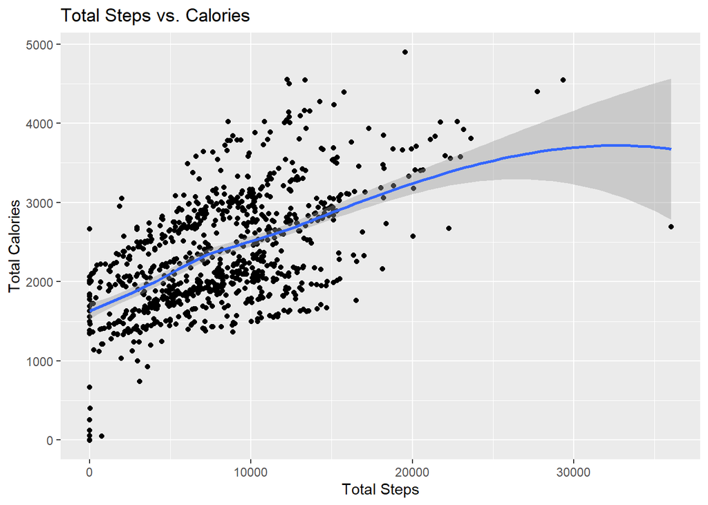

```r
#Total Steps vs Calories graph
daily_activity %>% ggplot(aes(x = TotalSteps, y = Calories))+
  geom_jitter() +
  geom_smooth() +
  labs(title="Total Steps vs. Calories",
       x = "Total Steps", y = "Total Calories")
```

## 2. Total Minutes Asleep vs Total Time in Bed graph

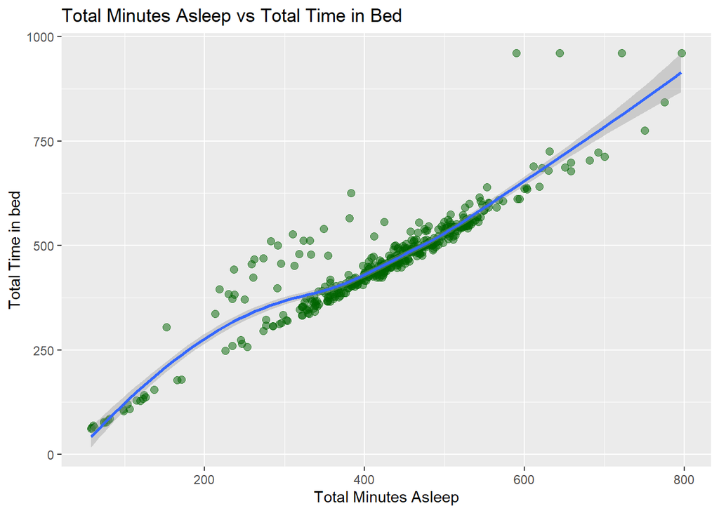

```r
#Total Minutes Asleep vs Total Time in Bed graph
daily_activity_sleep %>% ggplot(aes(x = TotalMinutesAsleep, y = TotalTimeInBed))+
  geom_jitter(color ="darkgreen", alpha = 0.5, size = 2.25)+
  geom_smooth()+
  labs(title = "Total Minutes Asleep vs Total Time in Bed",
       x = "Total Minutes Asleep", y = "Total Time in bed")
```

## 3. Average Total Intensity vs. Time Graph

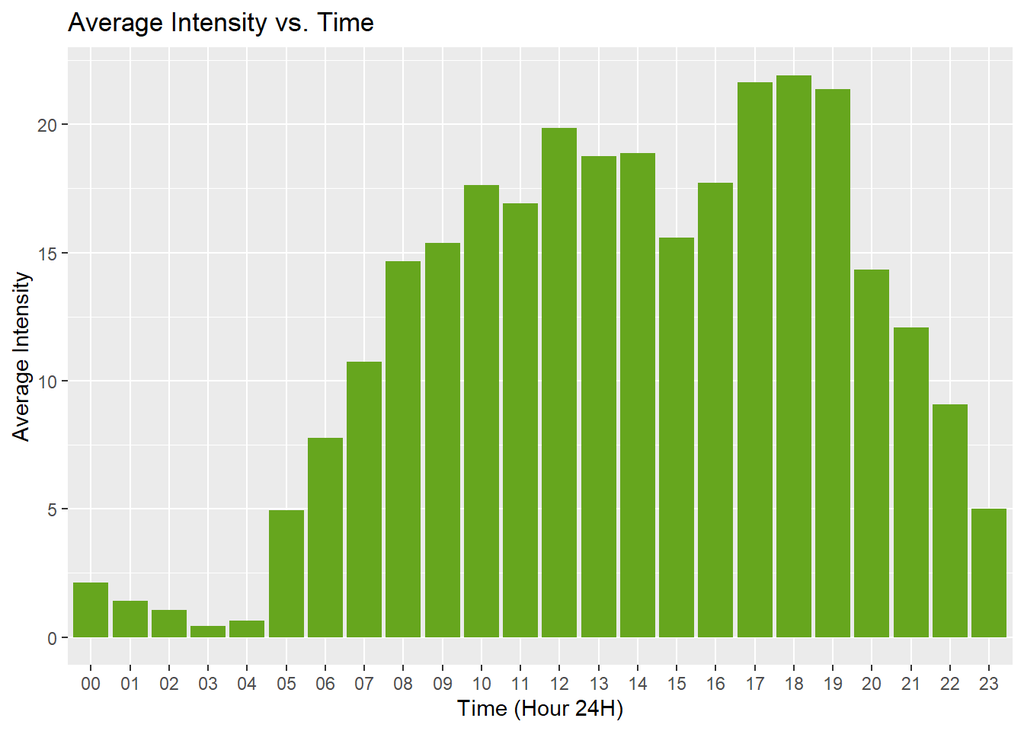

```r
#Average Total Intensity vs. Time
add_data_1 %>% ggplot(aes(x = hour, y = avg_intensity))+
  geom_histogram(stat = "identity", fill = "#66A61E", bins = 30)+
  labs(title="Average Intensity vs. Time",
       x = "Time (Hour 24H)", y = "Average Intensity")
```

## 4. Average Calories vs. Time Graph

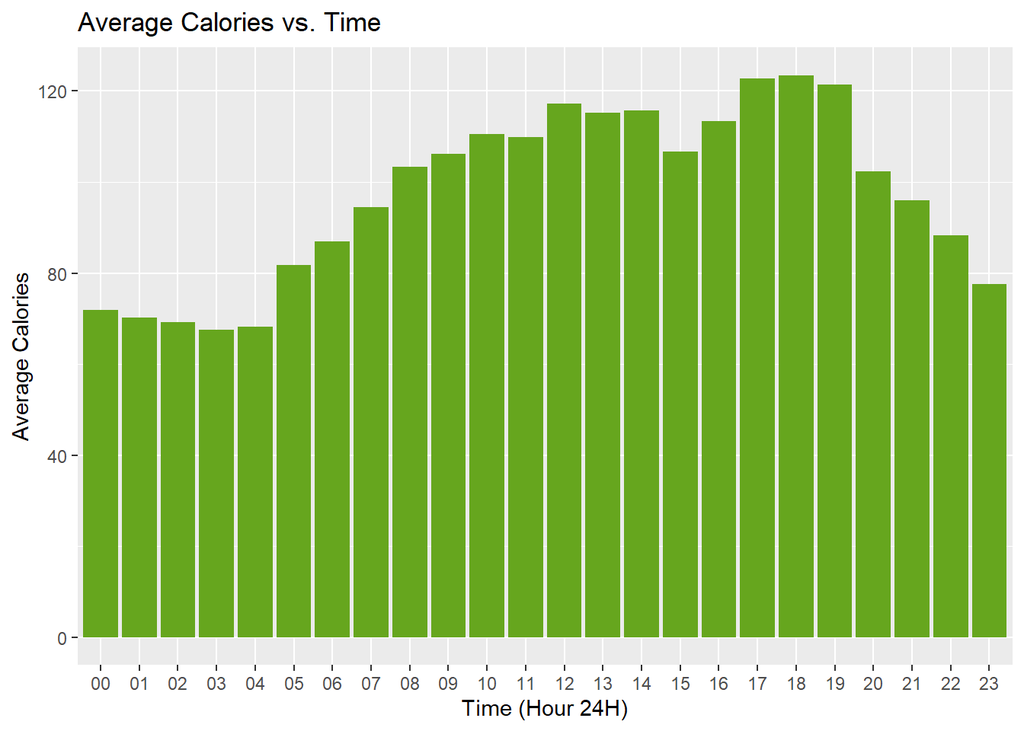

```r
#Average Calories vs. Time
add_data_1 %>% ggplot(aes(x = hour, y = avg_calories))+
  geom_histogram(stat = "identity", fill = "#66A61E")+
  labs(title="Average Calories vs. Time",
       x = "Time (Hour 24H)", y = "Average Calories")
```

## 5. Average Steps vs. Time Graph

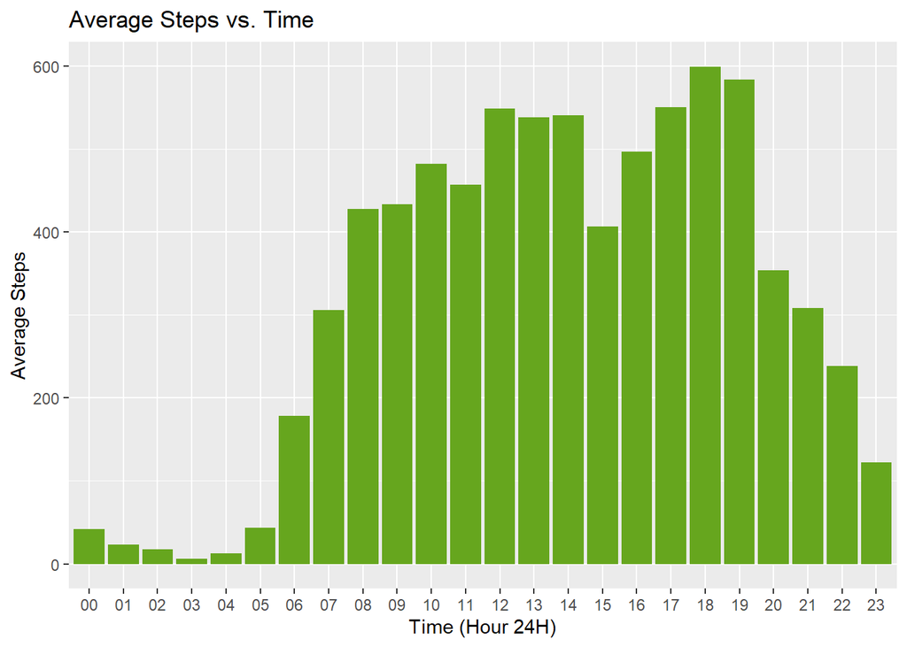

```r
#Average Steps vs. Time
add_data_1 %>% ggplot(aes(x = hour, y = avg_steps))+
  geom_histogram(stat = "identity", fill = "#66A61E")+
  labs(title="Average Steps vs. Time",
       x = "Time (Hour 24H)", y = "Average Steps")
```

## 6. Average Calories vs. Time Graph Filtered by Average Intensity

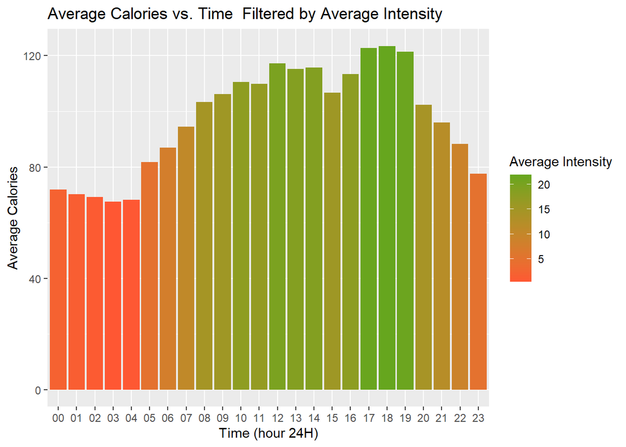

```r
#Average Calories vs. Time
add_data_1 %>% ggplot(aes(x = hour, y = avg_calories, fill = avg_intensity))+
  geom_col()+
  labs(x="Time (hour 24H)", y = "Average Calories",
       title="Average Calories vs. Time  Filtered by Average Intensity",
       fill = "Average Intensity")+
  scale_fill_gradient(low = "#FF5733", high = "#66A61E")
```

## 7. Average Steps vs. Time Graph Filtered by Average Intensity

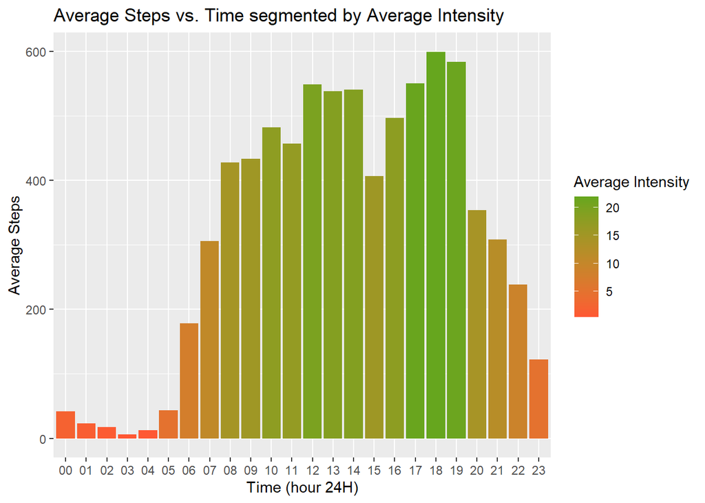

```r
#Average Steps vs. Time
add_data_1 %>% ggplot(aes(x = hour, y = avg_steps, fill = avg_intensity))+
  geom_col()+
  labs(x="Time (hour 24H)", y = "Average Steps",
       title="Average Steps vs. Time segmented by Average Intensity",
       fill = "Average Intensity")+
  scale_fill_gradient(low = "#FF5733", high = "#66A61E")
```

[figure not shown]

```r
add_data_2_dis %>% ggplot(aes(x = day_of_week, y = avg_distance, fill = Activity))+
  geom_col()+
  labs(x="Day", y = "Average Distance",
       title="Average Steps vs. Time segmented by Distances",
       fill = "Distances")+
  scale_fill_manual(
    breaks = names(custom_colors),
    values = custom_colors,
    labels = c("Very Active", "Moderately Active", "Lightly Active", "Sedentary Activity")
  )
```